# 타이타닉 데이터 분석

hwa

2022-08-08

## 1. 준비 작업(데이터 전처리)

### 1-1. 외부 데이터 불러오기(csv -> data.frame)

```r
df <- read.csv("./titanic/train.csv", header=T,
               na.strings = c("", " ", NA))    #문자열 불러올 때, NA 설정

# 데이터 유형 및 내부구조 확인
str(df)
```

```
## 'data.frame':    891 obs. of  12 variables:
##  $ PassengerId: int  1 2 3 4 5 6 7 8 9 10 ...
##  $ Survived   : int  0 1 1 1 0 0 0 0 1 1 ...
##  $ Pclass     : int  3 1 3 1 3 3 1 3 3 2 ...
##  $ Name       : chr  "Braund, Mr. Owen Harris" "Cumings, Mrs. John Bradley (Florence Briggs Thayer)" "Heikkinen, Miss. Laina" "Futrelle, Mrs. Jacques Heath (Lily May Peel)" ...
##  $ Sex        : chr  "male" "female" "female" "female" ...
##  $ Age        : num  22 38 26 35 35 NA 54 2 27 14 ...
##  $ SibSp      : int  1 1 0 1 0 0 0 3 0 1 ...
##  $ Parch      : int  0 0 0 0 0 0 0 1 2 0 ...
##  $ Ticket     : chr  "A/5 21171" "PC 17599" "STON/O2. 3101282" "113803" ...
##  $ Fare       : num  7.25 71.28 7.92 53.1 8.05 ...
##  $ Cabin      : chr  NA "C85" NA "C123" ...
##  $ Embarked   : chr  "S" "C" "S" "S" ...
```

- 컬럼(columns) 설명

PassengerId: 승객 번호 survivied: 생존여부 (1: 생존, 0: 사망) pclass: 좌석 등급 (1등급, 2등급, 3등급) sex: 성별 Age: 나이 sibsp: 형제 + 배우자 수 parch: 부모 + 자녀 수 ticket: 티켓 번호 fare: 좌석 요금 cabin: 선실 이름 embarked: 탑승 항구 (S, C, Q)

### 1-2. 데이터 파악하기

```r
# 차원 확인(행/열)
dim(df)
```

```
## [1] 891  12
```

```r
# 요약 통계량
summary(df)
```

```
##   PassengerId       Survived          Pclass          Name
##  Min.   :  1.0   Min.   :0.0000   Min.   :1.000   Length:891
##  1st Qu.:223.5   1st Qu.:0.0000   1st Qu.:2.000   Class :character
##  Median :446.0   Median :0.0000   Median :3.000   Mode  :character
##  Mean   :446.0   Mean   :0.3838   Mean   :2.309
##  3rd Qu.:668.5   3rd Qu.:1.0000   3rd Qu.:3.000
##  Max.   :891.0   Max.   :1.0000   Max.   :3.000
##
##      Sex                 Age            SibSp           Parch
##  Length:891         Min.   : 0.42   Min.   :0.000   Min.   :0.0000
##  Class :character   1st Qu.:20.12   1st Qu.:0.000   1st Qu.:0.0000
##  Mode  :character   Median :28.00   Median :0.000   Median :0.0000
##                     Mean   :29.70   Mean   :0.523   Mean   :0.3816
##                     3rd Qu.:38.00   3rd Qu.:1.000   3rd Qu.:0.0000
##                     Max.   :80.00   Max.   :8.000   Max.   :6.0000
##                     NA's   :177
##     Ticket               Fare           Cabin             Embarked
##  Length:891         Min.   :  0.00   Length:891         Length:891
##  Class :character   1st Qu.:  7.91   Class :character   Class :character
##  Mode  :character   Median : 14.45   Mode  :character   Mode  :character
##                     Mean   : 32.20
##                     3rd Qu.: 31.00
##                     Max.   :512.33
##
```

```r
#데이터의 앞/뒷부분 6개씩 출력
head(df)
```

```
##   PassengerId Survived Pclass
## 1           1        0      3
## 2           2        1      1
## 3           3        1      3
## 4           4        1      1
## 5           5        0      3
## 6           6        0      3
##                                                  Name    Sex Age SibSp Parch
## 1                             Braund, Mr. Owen Harris   male  22     1     0
## 2 Cumings, Mrs. John Bradley (Florence Briggs Thayer) female  38     1     0
## 3                              Heikkinen, Miss. Laina female  26     0     0
## 4        Futrelle, Mrs. Jacques Heath (Lily May Peel) female  35     1     0
## 5                            Allen, Mr. William Henry   male  35     0     0
## 6                                    Moran, Mr. James   male  NA     0     0
##             Ticket    Fare Cabin Embarked
## 1        A/5 21171  7.2500  <NA>        S
## 2         PC 17599 71.2833   C85        C
## 3 STON/O2. 3101282  7.9250  <NA>        S
## 4           113803 53.1000  C123        S
## 5           373450  8.0500  <NA>        S
## 6           330877  8.4583  <NA>        Q
```

```r
tail(df)
```

```
##     PassengerId Survived Pclass                                     Name    Sex
## 886         886        0      3     Rice, Mrs. William (Margaret Norton) female
## 887         887        0      2                    Montvila, Rev. Juozas   male
## 888         888        1      1             Graham, Miss. Margaret Edith female
## 889         889        0      3 Johnston, Miss. Catherine Helen "Carrie" female
## 890         890        1      1                    Behr, Mr. Karl Howell   male
## 891         891        0      3                      Dooley, Mr. Patrick   male
##     Age SibSp Parch     Ticket   Fare Cabin Embarked
## 886  39     0     5     382652 29.125  <NA>        Q
## 887  27     0     0     211536 13.000  <NA>        S
## 888  19     0     0     112053 30.000   B42        S
## 889  NA     1     2 W./C. 6607 23.450  <NA>        S
## 890  26     0     0     111369 30.000  C148        C
## 891  32     0     0     370376  7.750  <NA>        Q
```

### 1-3. 변수 계산 및 생성

```r
df$Family <- df$SibSp + df$Parch
```

- SibSp(형제+배우자수)와 Parch(부모+자녀수) 변수를 통합 ==> **Family(동반가족수) 변수 생성**

```r
# 가족/혼자 변수 생성
df$family_num <- cut(df$Family, breaks=c(-1,0.1,10), labels=c("alone","family"))
table(df$family_num)
```

```
##
##  alone family
##    537    354
```

```r
# 연령대 변수 생성
df$Age_group <- cut(df$Age, breaks=c(0,10,20,30,40,50,60,90),
                    labels=c("0~9","10~19","20~29","30~39","40~49","50~59","over 60"))
table(df$Age_group)
```

```
##
##     0~9   10~19   20~29   30~39   40~49   50~59 over 60
##      64     115     230     155      86      42      22
```

### 1-4. 결측치 분포 확인하기

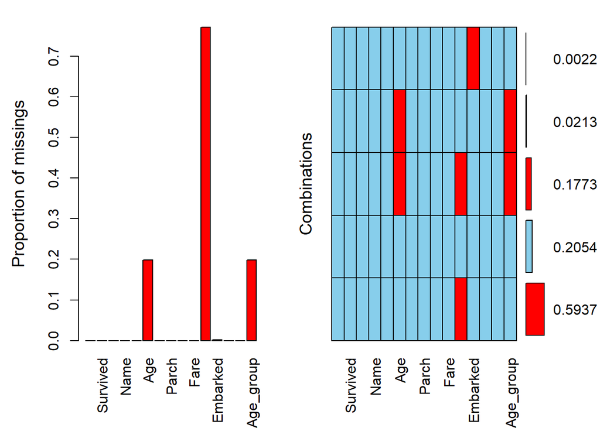

```r
library(VIM)
aggr(df, numbers=T, prop=T)
```

- PassengerId(승객번호)와 ticket(티켓번호)은 고유값을 가짐 ==> 분석변수에서 제외
- SibSp(형제+배우자수)와 Parch(부모+자녀수) 변수를 합하여 Family(동반가족수) 변수로 생성 ==> 분석변수에서 제외
- cabin(선실이름) 결측값 687개(77%) ==> 분석변수에서 제외
- Embarked(탑승항구) 결측값 2개(0.2%) ==> **샘플링**하여 결측치 대체
- Age(나이) 결측값 177개(20%) ==> **결측치 제외** 후 연령별 분석 예정

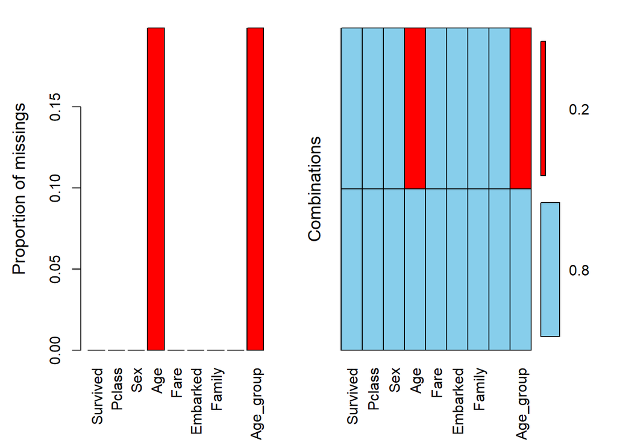

```r
# 사용할 데이터만 추출
titanic_df <- df[c(2,3,5,6,10,12,13,14,15)]

set.seed(123)       # 랜덤적인 값을 고정

# Embarked에서 샘플링하여 결측치 대체
titanic_df$Embarked[is.na(titanic_df$Embarked)] <- sample(na.omit(titanic_df$Embarked), 2)
#sum(is.na(titanic_df$Embarked))     # Embarked의 NA 갯수

# 결측치 분포 확인
aggr(titanic_df, numbers=T, prop=T)
```

### 1-5. 이상치 확인하기

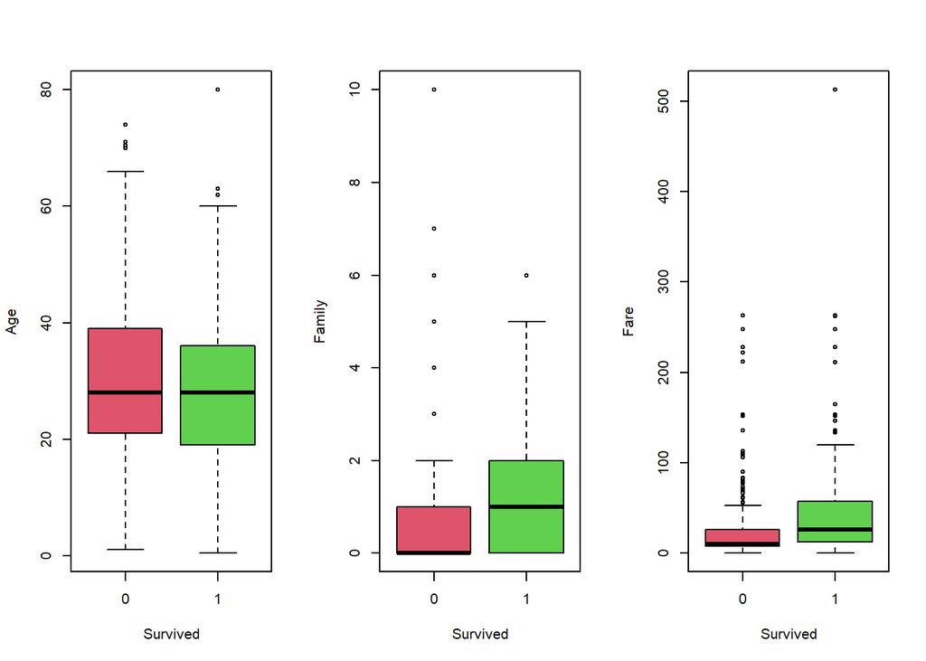

```r
#str(titanic_df)

par(mfrow=c(1,3))
boxplot(Age ~ Survived, data=titanic_df, col=2:3)
boxplot(Family ~ Survived, data=titanic_df, col=2:3)
boxplot(Fare ~ Survived, data=titanic_df, col=2:3)
```

```r
# Age(나이)의 이상치
sort(boxplot.stats(titanic_df$Age)$out)
```

```
## [1] 66.0 70.0 70.0 70.5 71.0 71.0 74.0 80.0
```

- Age(나이) 변수의 이상치 범위는 66세~80세 ==> 고령자도 크루즈 여행이 가능하다고 사료되어 **Age 이상치를 제거하지 않고 사용**

```r
# Family(동반가족수)의 이상치
sort(boxplot.stats(titanic_df$Family)$out)
```

```
##  [1]  3  3  3  3  3  3  3  3  3  3  3  3  3  3  3  3  3  3  3  3  3  3  3  3  3
## [26]  3  3  3  3  4  4  4  4  4  4  4  4  4  4  4  4  4  4  4  5  5  5  5  5  5
## [51]  5  5  5  5  5  5  5  5  5  5  5  5  5  5  5  5  6  6  6  6  6  6  6  6  6
## [76]  6  6  6  7  7  7  7  7  7 10 10 10 10 10 10 10
```

- Family(동반가족수) 변수의 이상치 범위는 3명~10명 ==> 대가족으로 크루즈 여행이 가능하다고 사료되어 **Family 이상치를 제거하지 않고 사용**

```r
# Fare(좌석 요금)의 이상치
sort(round(boxplot.stats(titanic_df$Fare)$out,0))
```

```
##   [1]  67  67  69  69  70  70  70  70  70  70  70  71  71  71  74  74  74  74
##  [19]  74  75  76  77  77  77  77  77  78  78  78  78  78  79  79  79  79  79
##  [37]  79  80  80  80  80  80  82  82  82  83  83  83  83  83  86  86  86  89
##  [55]  89  90  90  90  90  91  91  94  94 106 106 109 109 111 111 111 111 113
##  [73] 113 113 120 120 120 120 134 134 134 134 136 136 136 147 147 152 152 152
##  [91] 152 153 153 153 165 165 211 211 211 212 222 228 228 228 228 248 248 262
## [109] 262 263 263 263 263 512 512 512
```

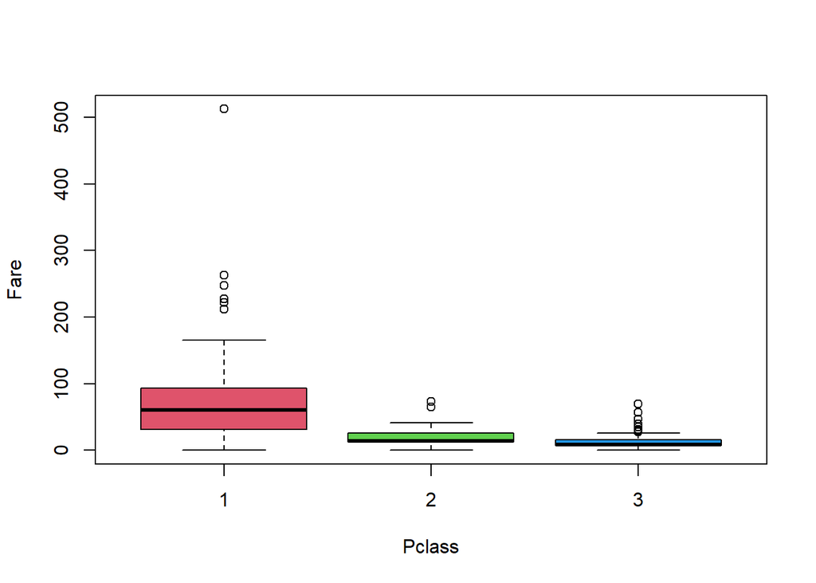

```r
#summary(titanic_df[,7])   # 범위(최대-최소), 평균

#좌석등급과 좌석요금의 관계성
par(mfrow=c(1,1))
boxplot(Fare ~ Pclass, data=titanic_df, col=2:4)
```

```r
aggregate(titanic_df[,c(7,1)],
          by=list(Pclass=titanic_df$Pclass), FUN=mean)
```

```
##   Pclass    Family  Survived
## 1      1 0.7731481 0.6296296
## 2      2 0.7826087 0.4728261
## 3      3 1.0081466 0.2423625
```

- Fare(좌석 요금) 변수의 이상치 범위는 67~512임이고, Pclass(좌석 등급)과 관련성이 있음. 1등급일수록 요금이 비쌈 ==> **독립변수로 Fare 대신 Pclass을 선택**

혹은 좌석요금 이상치에 좌석등급별 평균값을 대체?!

## 2. 데이터 탐색 및 시각화

### 2-1. 수치형 변수의 데이터 탐색

```r
# 요약 통계량
summary(titanic_df[,4:7])
```

```
##       Age             Fare          Embarked             Family
##  Min.   : 0.42   Min.   :  0.00   Length:891         Min.   : 0.0000
##  1st Qu.:20.12   1st Qu.:  7.91   Class :character   1st Qu.: 0.0000
##  Median :28.00   Median : 14.45   Mode  :character   Median : 0.0000
##  Mean   :29.70   Mean   : 32.20                      Mean   : 0.9046
##  3rd Qu.:38.00   3rd Qu.: 31.00                      3rd Qu.: 1.0000
##  Max.   :80.00   Max.   :512.33                      Max.   :10.0000
##  NA's   :177
```

```r
mean(titanic_df$Age, na.rm=T)    #평균 산출
```

```
## [1] 29.69912
```

```r
sd(titanic_df$Age, na.rm=T)     #표준편차 산출
```

```
## [1] 14.5265
```

```r
mean(titanic_df$Fare)     #평균 산출
```

```
## [1] 32.20421
```

```r
sd(titanic_df$Fare)      #표준편차 산출
```

```
## [1] 49.69343
```

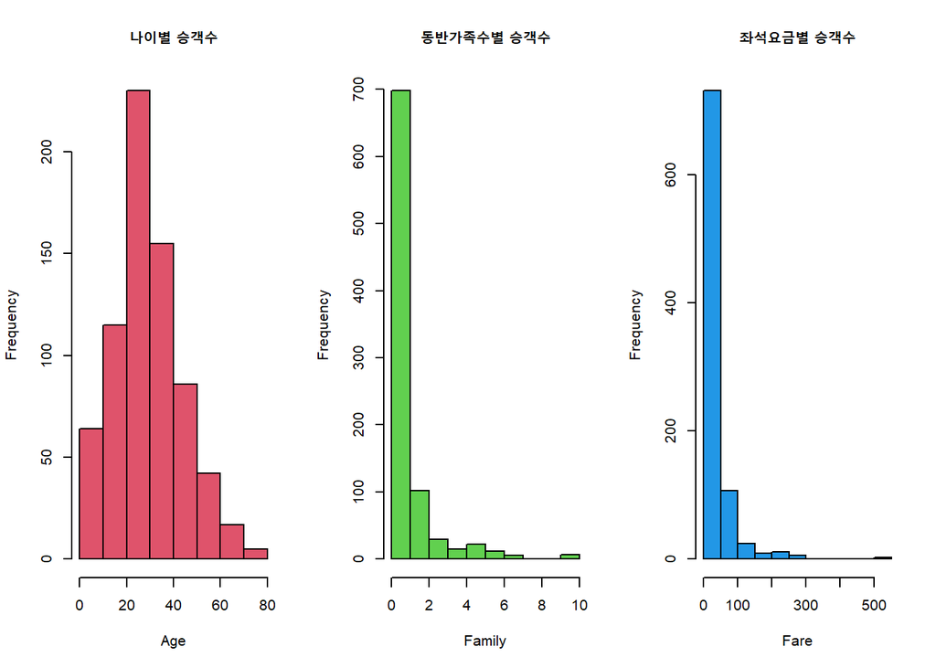

```r
#히스토그램 작성
par(mfrow=c(1,3))
hist(titanic_df$Age, col=2, main='나이별 승객수', xlab='Age')
hist(titanic_df$Family, col=3, main='동반가족수별 승객수', xlab='Family')
hist(titanic_df$Fare, col=4, main='좌석요금별 승객수', xlab='Fare')
```

### 2-2. 범주형 변수의 데이터 탐색

```r
#범주형 데이터 빈도수와 비율
'생존여부'
```

```
## [1] "생존여부"
```

```r
table(titanic_df$Survived)
```

```
##
##   0   1
## 549 342
```

```r
round(prop.table(table(titanic_df$Survived)),2)
```

```
##
##    0    1
## 0.62 0.38
```

```r
'좌석등급'
```

```
## [1] "좌석등급"
```

```r
table(titanic_df$Pclass)
```

```
##
##   1   2   3
## 216 184 491
```

```r
round(prop.table(table(titanic_df$Pclass)),2)
```

```
##
##    1    2    3
## 0.24 0.21 0.55
```

```r
'성별'
```

```
## [1] "성별"
```

```r
table(titanic_df$Sex)
```

```
##
## female   male
##    314    577
```

```r
round(prop.table(table(titanic_df$Sex)),2)
```

```
##
## female   male
##   0.35   0.65
```

```r
'탑승항구'
```

```
## [1] "탑승항구"
```

```r
table(titanic_df$Embarked)
```

```
##
##   C   Q   S
## 168  77 646
```

```r
round(prop.table(table(titanic_df$Embarked)),2)
```

```
##
##    C    Q    S
## 0.19 0.09 0.73
```

```r
'가족동반'
```

```
## [1] "가족동반"
```

```r
table(titanic_df$family_num)
```

```
##
##  alone family
##    537    354
```

```r
round(prop.table(table(titanic_df$family_num)),2)
```

```
##
##  alone family
##    0.6    0.4
```

```r
'연령대'
```

```
## [1] "연령대"
```

```r
table(titanic_df$Age_group)
```

```
##
##     0~9   10~19   20~29   30~39   40~49   50~59 over 60
##      64     115     230     155      86      42      22
```

```r
round(prop.table(table(titanic_df$Age_group)),2)
```

```
##
##     0~9   10~19   20~29   30~39   40~49   50~59 over 60
##    0.09    0.16    0.32    0.22    0.12    0.06    0.03
```

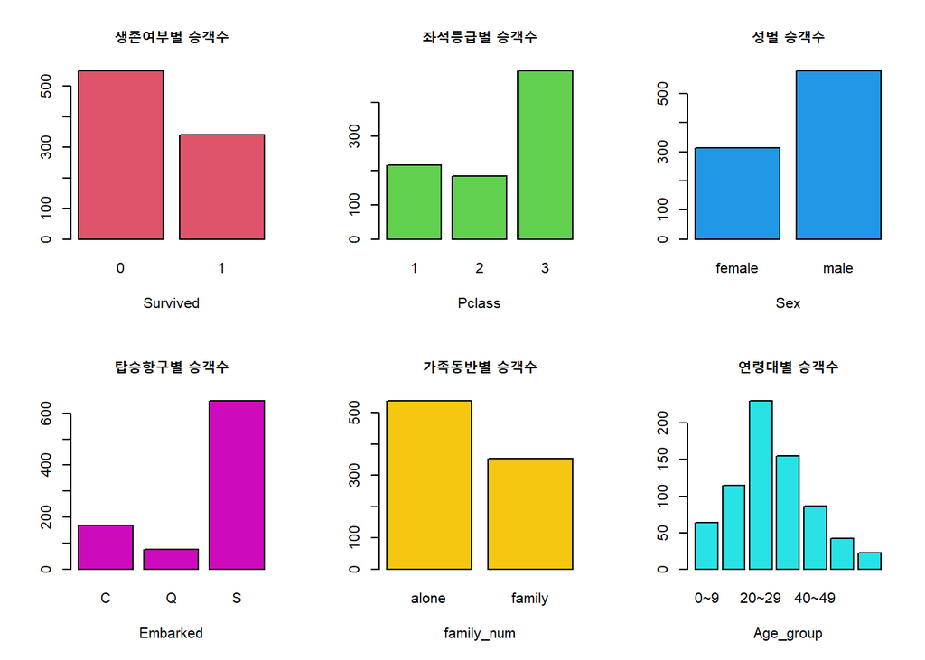

```r
#막대그래프 작성
par(mfrow=c(2,3))
barplot(table(titanic_df$Survived), col=2, main='생존여부별 승객수', xlab='Survived')
barplot(table(titanic_df$Pclass), col=3, main='좌석등급별 승객수', xlab='Pclass')
barplot(table(titanic_df$Sex), col=4, main='성별 승객수', xlab='Sex')
barplot(table(titanic_df$Embarked), col=6, main='탑승항구별 승객수', xlab='Embarked')
barplot(table(titanic_df$family_num), col=7, main='가족동반별 승객수', xlab='family_num')
barplot(table(titanic_df$Age_group), col=5, main='연령대별 승객수', xlab='Age_group')
```

## 3-1. 유형별 생존여부

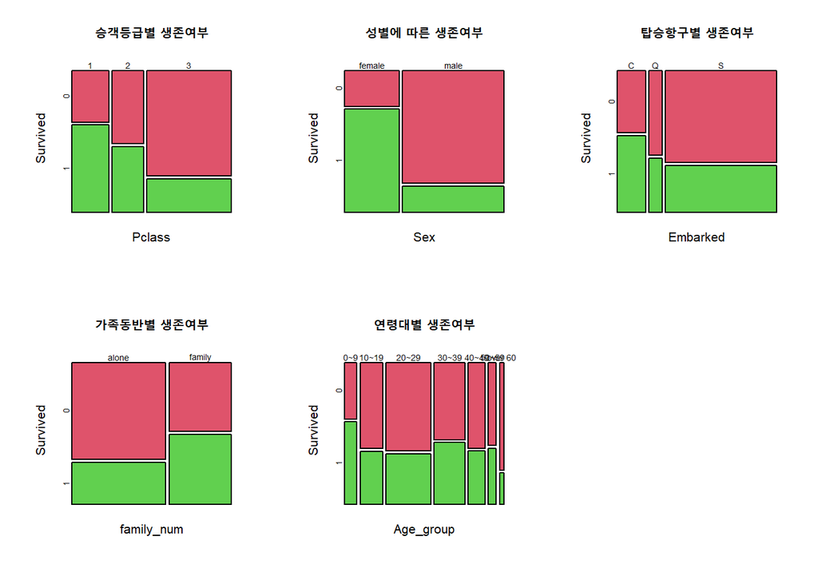

```r
par(mfrow=c(2,3))
mosaicplot(Pclass ~ Survived, data=titanic_df, col = 2:3, main='승객등급별 생존여부')
mosaicplot(Sex ~ Survived, data=titanic_df, col = 2:3, main='성별에 따른 생존여부')
mosaicplot(Embarked ~ Survived, data=titanic_df, col = 2:3, main='탑승항구별 생존여부')
mosaicplot(family_num ~ Survived, data=titanic_df, col = 2:3, main='가족동반별 생존여부')
mosaicplot(Age_group ~ Survived, data=titanic_df, col = 2:3, main='연령대별 생존여부')
```

## 3-2. 집단별로 평균 (=>생존율)

```r
aggregate(titanic_df$Survived,
          by=list(Pclass=titanic_df$Pclass), FUN=mean)
```

```
##   Pclass         x
## 1      1 0.6296296
## 2      2 0.4728261
## 3      3 0.2423625
```

```r
aggregate(titanic_df$Survived,
          by=list(Sex=titanic_df$Sex), FUN=mean)
```

```
##      Sex         x
## 1 female 0.7420382
## 2   male 0.1889081
```

```r
aggregate(titanic_df$Survived,
          by=list(Embarked=titanic_df$Embarked), FUN=mean)
```

```
##   Embarked         x
## 1        C 0.5535714
## 2        Q 0.3896104
## 3        S 0.3390093
```

```r
aggregate(titanic_df$Survived,
          by=list(family_num=titanic_df$family_num), FUN=mean)
```

```
##   family_num         x
## 1      alone 0.3035382
## 2     family 0.5056497
```

```r
aggregate(titanic_df$Survived,
          by=list(Age_group=titanic_df$Age_group), FUN=mean)
```

```
##   Age_group         x
## 1       0~9 0.5937500
## 2     10~19 0.3826087
## 3     20~29 0.3652174
## 4     30~39 0.4451613
## 5     40~49 0.3837209
## 6     50~59 0.4047619
## 7   over 60 0.2272727
```